# Outliers – Complete Notes

## 🔹 What is an Outlier?

- A data point that is **very different from other observations**
- Example: The point where a student studied 9 hours but scored 30 marks is an outlier because it doesn’t follow the usual pattern most students who study more hours score higher, but this one scored much lower than expected.

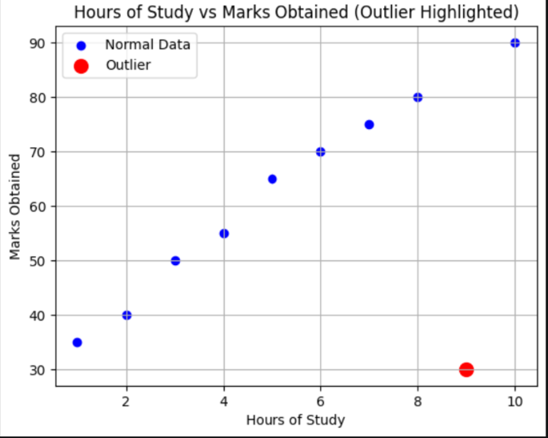

In this dataset, most phones follow a **normal trend**: as RAM increases, the price also increases. For example:

- **Samsung A1:** 2 GB → $100
- **OnePlus 7:** 6 GB → $400
- **OnePlus 8:** 10 GB → $850

This shows a **predictable pattern**: higher RAM usually means a higher price.

However, **two phones break this trend**:

- **iPhone (4 GB RAM, $1000):** This phone is **much more expensive than expected** for its RAM. Normal phones with 4 GB RAM cost around $200–$300.
  - ✅ Outlier on the **high-price side**.
- **Redmi Note (12 GB RAM, $200):** This phone is **much cheaper than expected** for its RAM. Normal phones with 12 GB RAM cost close to $1000.
  - ✅ Outlier on the **low-price side**.

**Key idea:** Outliers are points that **deviate significantly from the expected trend**. Here, the expected trend is: *more RAM → higher price*.

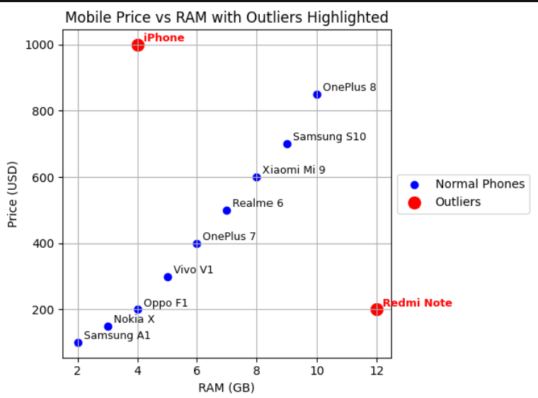

## 🔹 Why Outliers Matter

- Can **distort machine learning models**
- Affect accuracy and predictions

## 🔹 Impact on ML Algorithms

| Highly Affected | Less Affected |
| --- | --- |
| 1) Linear Regression | 1) Decision Trees |
| 2) Logistic Regression | 2) Random Forest |
| 3) K-Means Clustering | 3) Gradient Boosting |
| 4) Neural Networks / Deep Learning |  |

> **Why?** Affected ones depend on **distance/weights**.

## 🔹 Are Outliers Always Bad? ❌ No!

| Remove When | Keep When |
| --- | --- |
| 1) Clearly a **data error** (e.g., age = 830) | 1) They are **meaningful** |
| 2) Noise / measurement error | 2) Fraud detection |
|  | 3) Anomaly detection |

## 🔹 Challenges with Outliers

- Easy to detect ❌
- Hard to decide: **Remove? Keep? Modify?**

# Handeling the Outliers

## 1) Z-Score Method for Outlier Detection

### 📌 Requirement: Data Must Be Normally Distributed

- The Z-score method **only works when the data follows a normal (bell-curve) distribution**.
- In a normal distribution:
  - ~68% of data falls within **±1 standard deviation** of the mean
  - ~95% falls within **±2 standard deviations**
  - ~**99.7%** falls within **±3 standard deviations**

> ⚠️ If your column is **skewed** (not symmetric), Z-score is **not the right method**. Use IQR instead.

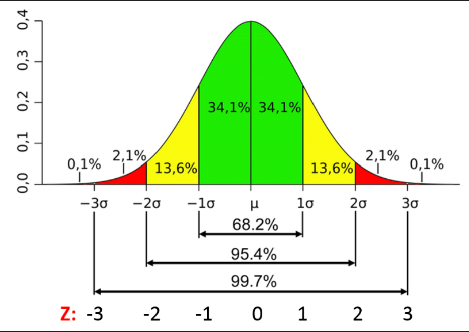

### 📌 The Z-Score Formula

$$ Z = \frac{x - \mu}{\sigma} $$

Where:

- $x$ = individual data point
- $\mu$ = mean of the column
- $\sigma$ = standard deviation of the column

**Interpretation:**

- Z-score tells you **how many standard deviations** a data point is from the mean.
- If $Z > 3$ or $Z < -3$ → the data point is an **outlier**.
- The safe range is: $-3 \leq Z \leq 3$

### 📌 Calculating Boundaries (Upper & Lower Limits)

Instead of computing Z for every point, you can directly compute the **boundary values**:

$$ \text{Upper Limit} = \mu + 3\sigma $$ $$ \text{Lower Limit} = \mu - 3\sigma $$

Any value **above the upper limit** or **below the lower limit** is an outlier.

### 📌 Outlier Treatment Techniques

Once outliers are identified, there are **two main ways** to handle them:

#### 1. Trimming (Removal)

- Simply **remove the rows** containing outlier values.
- Use when outliers are due to errors or noise.

#### 2. Capping (Winsorization)

- **Replace** outlier values with the nearest boundary value.
- Values above upper limit → set to upper limit
- Values below lower limit → set to lower limit
- Preserves the number of rows in the dataset.

### 📌 Key Reminders

| Point | Detail |
| --- | --- |
| When to use Z-score | Only when the column is **normally distributed** |
| Threshold | Data outside **±3 standard deviations** is an outlier |
| Trimming | Removes rows → dataset shrinks |
| Capping | Replaces values → dataset size stays same |
| Not suitable for | Skewed distributions (use IQR method instead) |

### 📌 Practical Implementation – Z-Score (Trimming & Capping)

We'll use the **Titanic dataset** from seaborn a real-world dataset. We'll apply Z-score outlier detection on the **`age`** column (which is approximately normally distributed).

```python
import pandas as pd
import matplotlib.pyplot as plt
import seaborn as sns

# Load Titanic dataset
df = sns.load_dataset('titanic')
df = df[['age', 'fare', 'pclass', 'survived' ]].dropna()  # keep relevant cols, drop nulls

print("Shape:", df.shape)
df.head()
```

```
Shape: (714, 4)
```

|  | age | fare | pclass | survived |
| --- | --- | --- | --- | --- |
| 0 | 22.0 | 7.2500 | 3 | 0 |
| 1 | 38.0 | 71.2833 | 1 | 1 |
| 2 | 26.0 | 7.9250 | 3 | 1 |
| 3 | 35.0 | 53.1000 | 1 | 1 |
| 4 | 35.0 | 8.0500 | 3 | 0 |

**Step 1: Check if `age`, `fare`, `pclass` column is normally distributed**

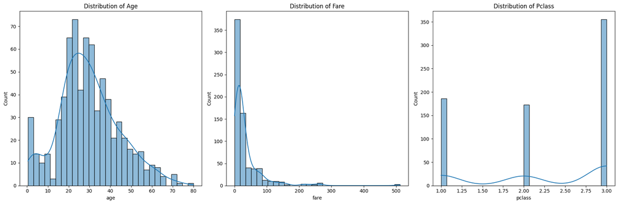

```python
fig, axes = plt.subplots(1, 3, figsize=(18, 6))

axes = axes.flatten()

sns.histplot(df['age'], kde=True, bins=30, ax=axes[0])
axes[0].set_title('Distribution of Age')

sns.histplot(df['fare'], kde=True, bins=30, ax=axes[1])
axes[1].set_title('Distribution of Fare')

sns.histplot(df['pclass'], kde=True, bins=30, ax=axes[2])
axes[2].set_title('Distribution of Pclass')

plt.tight_layout()
plt.show()
```

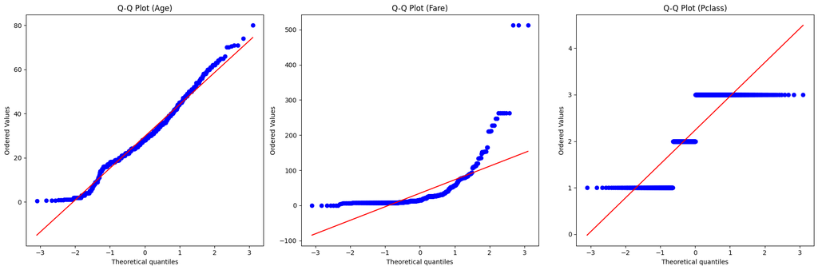

```python
import scipy.stats as stats

fig, axes = plt.subplots(1, 3, figsize=(18, 6))

# Q-Q plot for Age
stats.probplot(df['age'].dropna(), dist="norm", plot=axes[0])
axes[0].set_title('Q-Q Plot (Age)')

# Q-Q plot for Fare
stats.probplot(df['fare'].dropna(), dist="norm", plot=axes[1])
axes[1].set_title('Q-Q Plot (Fare)')

# Q-Q plot for Pclass
stats.probplot(df['pclass'].dropna(), dist="norm", plot=axes[2])
axes[2].set_title('Q-Q Plot (Pclass)')

plt.tight_layout()
plt.show()
```

### Outlier Analysis Summary

> Only **age** appears to follow a normal distribution.  
> **fare** and **pclass** are *not* normally distributed, so the **Z-score method** is **not suitable** for outlier removal.

```python
df[['age', 'fare', 'pclass']].describe()
```

|  | age | fare | pclass |
| --- | --- | --- | --- |
| count | 714.000000 | 714.000000 | 714.000000 |
| mean | 29.699118 | 34.694514 | 2.236695 |
| std | 14.526497 | 52.918930 | 0.838250 |
| min | 0.420000 | 0.000000 | 1.000000 |
| 25% | 20.125000 | 8.050000 | 1.000000 |
| 50% | 28.000000 | 15.741700 | 2.000000 |
| 75% | 38.000000 | 33.375000 | 3.000000 |
| max | 80.000000 | 512.329200 | 3.000000 |

**Step 2: Calculate Upper & Lower Limits using Z-score (mean ± 3σ)**

```python
mean = df['age'].mean()
std = df['age'].std()

upper_limit = int(mean + 3 * std)
lower_limit = int(mean - 3 * std)

print(f"Mean: {mean:.2f}")
print(f"Std:  {std:.2f}")
print(f"Upper Limit: {upper_limit}")
print(f"Lower Limit: {lower_limit}")
```

```
Mean: 29.70
Std:  14.53
Upper Limit: 73
Lower Limit: -13
```

**Step 3: Find outliers**

```python
# Find outliers
outliers = df[(df['age'] > upper_limit) | (df['age'] < lower_limit)]
print(f"Total rows: {df.shape[0]}")
print(f"Outliers found: {outliers.shape[0]}")
outliers
```

```
Total rows: 714
Outliers found: 2
```

|  | age | fare | pclass | survived |
| --- | --- | --- | --- | --- |
| 630 | 80.0 | 30.000 | 1 | 1 |
| 851 | 74.0 | 7.775 | 3 | 0 |

#### Technique 1: Trimming (Remove Outlier Rows)

```python
# Trimming: Remove rows with outliers
df_trimmed = df[(df['age'] >= lower_limit) & (df['age'] <= upper_limit)]

print(f"Before trimming: {df.shape[0]} rows")
print(f"After trimming:  {df_trimmed.shape[0]} rows")
print(f"Rows removed:    {df.shape[0] - df_trimmed.shape[0]}")
```

```
Before trimming: 714 rows
After trimming:  712 rows
Rows removed:    2
```

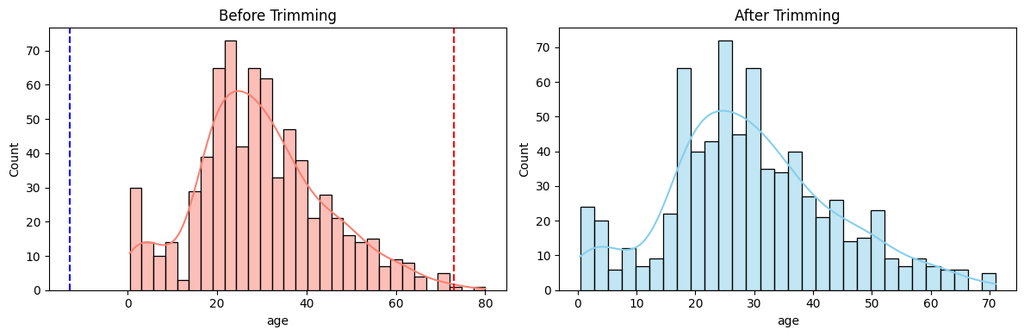

```python
# Compare distribution: Before vs After Trimming
fig, axes = plt.subplots(1, 2, figsize=(12, 4))

axes = axes.flatten()

sns.histplot(df['age'], kde=True, bins=30, ax=axes[0], color='salmon')
axes[0].set_title('Before Trimming')
axes[0].axvline(upper_limit, color='red', linestyle='--', label=f'Upper: {upper_limit:.1f}')
axes[0].axvline(lower_limit, color='blue', linestyle='--', label=f'Lower: {lower_limit:.1f}')

sns.histplot(df_trimmed['age'], kde=True, bins=30, ax=axes[1], color='skyblue')
axes[1].set_title('After Trimming')

plt.tight_layout()
plt.show()
```

#### Technique 2: Capping (Replace Outliers with Boundary Values)

```python
df_capped = df.copy()

df_capped['age'] = df_capped['age'].apply(
    lambda x: upper_limit if x > upper_limit else (lower_limit if x < lower_limit else x)
)

print(f"Before capping - Age range: {df['age'].min():.1f} to {df['age'].max():.1f}")
print(f"After capping  - Age range: {df_capped['age'].min():.1f} to {df_capped['age'].max():.1f}")
```

```
Before capping - Age range: 0.4 to 80.0
After capping  - Age range: 0.4 to 73.0
```

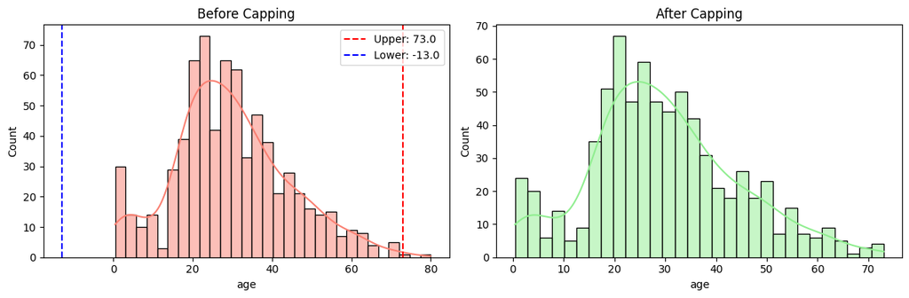

```python
# Compare distribution: Before vs After Capping
fig, axes = plt.subplots(1, 2, figsize=(12, 4))

sns.histplot(df['age'], kde=True, bins=30, ax=axes[0], color='salmon')
axes[0].axvline(upper_limit, color='red', linestyle='--', label=f'Upper: {upper_limit:.1f}')
axes[0].axvline(lower_limit, color='blue', linestyle='--', label=f'Lower: {lower_limit:.1f}')
axes[0].set_title('Before Capping')
axes[0].legend()

sns.histplot(df_capped['age'], kde=True, bins=30, ax=axes[1], color='lightgreen')
axes[1].set_title('After Capping')

plt.tight_layout()
plt.show()
```

### Side-by-Side Comparison: Trimming vs Capping

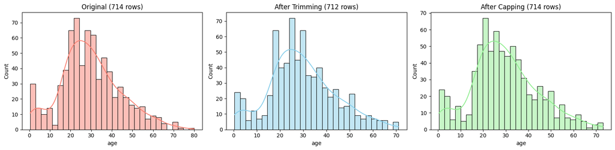

|  | Original | Trimmed | Capped |
| --- | --- | --- | --- |
| count | 714.00 | 712.00 | 714.00 |
| mean | 29.70 | 29.57 | 29.69 |
| std | 14.53 | 14.33 | 14.49 |
| min | 0.42 | 0.42 | 0.42 |
| 25% | 20.12 | 20.00 | 20.12 |
| 50% | 28.00 | 28.00 | 28.00 |
| 75% | 38.00 | 38.00 | 38.00 |
| max | 80.00 | 71.00 | 73.00 |

```python
# Final comparison: Original vs Trimmed vs Capped distributions
fig, axes = plt.subplots(1, 3, figsize=(16, 4))

axes = axes.flatten()

# Original
sns.histplot(df['age'], kde=True, bins=30, ax=axes[0], color='salmon')
axes[0].set_title(f'Original ({df.shape[0]} rows)')

# After trimming
sns.histplot(df_trimmed['age'], kde=True, bins=30, ax=axes[1], color='skyblue')
axes[1].set_title(f'After Trimming ({df_trimmed.shape[0]} rows)')

# After capping
sns.histplot(df_capped['age'], kde=True, bins=30, ax=axes[2], color='lightgreen')
axes[2].set_title(f'After Capping ({df_capped.shape[0]} rows)')

plt.tight_layout()
plt.show()

# Summary stats comparison
summary = pd.DataFrame({
    'Original': df['age'].describe(),
    'Trimmed': df_trimmed['age'].describe(),
    'Capped': df_capped['age'].describe()
}).round(2)

summary
```

## 2) IQR (BOX PLOT) Method for Outlier Detection

### 📌 Why IQR?

- Z-score works only for **normally distributed** data.
- For **skewed data**, use the **IQR (Interquartile Range)** method.

### 📌 What is IQR?

- **Q1 (25th percentile):** 25% of data falls below this value
- **Q3 (75th percentile):** 75% of data falls below this value
- **IQR = Q3 - Q1** → the range of the **middle 50%** of data

### 📌 Calculating Boundaries

$$ \text{Lower Limit} = Q1 - 1.5 \times IQR $$ $$ \text{Upper Limit} = Q3 + 1.5 \times IQR $$

Any value **below the lower limit** or **above the upper limit** is an outlier.

> The **1.5 multiplier** is the standard convention (used in boxplots). Use **3×IQR** for detecting only **extreme outliers**.

### 📌 Key Reminders

| Point | Detail |
| --- | --- |
| When to use IQR | Works for **any distribution** (normal or skewed) |
| Based on | Percentiles (Q1, Q3), not mean/std |
| Threshold | 1.5×IQR (standard) or 3×IQR (extreme only) |
| Trimming | Remove rows outside limits → dataset shrinks |
| Capping | Replace outlier values with boundary limits → size preserved |

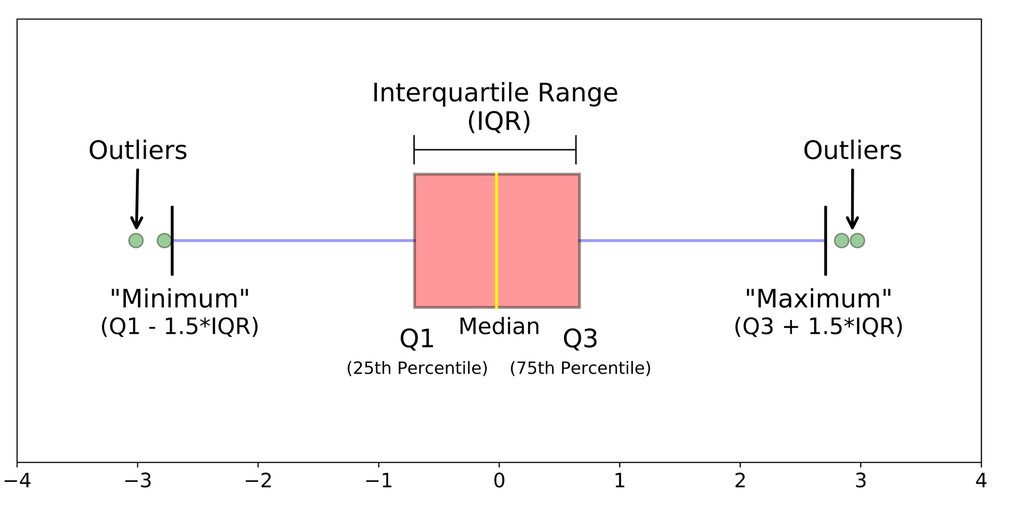

### 📌 Practical Implementation – IQR (Trimming & Capping)

We'll use the **`fare`** column from the same Titanic dataset — it was **skewed** (not normal), so Z-score won't work here. IQR is the right choice.

**Step 1: Confirm `fare` is skewed (not suitable for Z-score)**

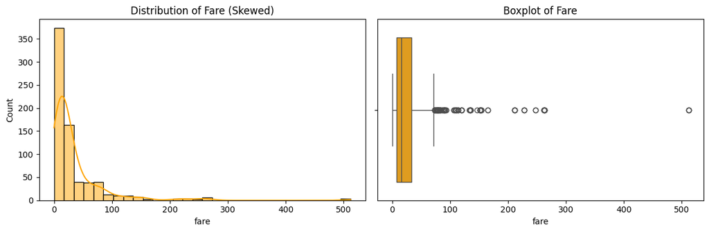

```
Skewness: 4.65
```

```python
# Create figure
fig, axes = plt.subplots(1, 2, figsize=(12, 4))

# Histogram
sns.histplot(df['fare'], kde=True, bins=30, color='orange', ax=axes[0])
axes[0].set_title('Distribution of Fare (Skewed)')

# Boxplot
sns.boxplot(x=df['fare'], color='orange', ax=axes[1])
axes[1].set_title('Boxplot of Fare')

plt.tight_layout()
plt.show()

# Skewness
print(f"Skewness: {df['fare'].skew():.2f}")  # high skewness → IQR is better
```

**Step 2: Calculate Q1, Q3, IQR and Boundaries**

```python
Q1 = df['fare'].quantile(0.25)
Q3 = df['fare'].quantile(0.75)
IQR = Q3 - Q1

lower_limit_iqr = Q1 - 1.5 * IQR
upper_limit_iqr = Q3 + 1.5 * IQR

print(f"Q1 (25th percentile): {Q1:.2f}")
print(f"Q3 (75th percentile): {Q3:.2f}")
print(f"IQR (Q3 - Q1):        {IQR:.2f}")
print(f"Lower Limit:           {lower_limit_iqr:.2f}")
print(f"Upper Limit:           {upper_limit_iqr:.2f}")
```

```
Q1 (25th percentile): 8.05
Q3 (75th percentile): 33.38
IQR (Q3 - Q1):        25.32
Lower Limit:           -29.94
Upper Limit:           71.36
```

**Step 3: Find outliers**

```python
# Find outliers using IQR
outliers_iqr = df[(df['fare'] > upper_limit_iqr) | (df['fare'] < lower_limit_iqr)]
print(f"Total rows: {df.shape[0]}")
print(f"Outliers found: {outliers_iqr.shape[0]}")
outliers_iqr['fare'].head(10)
```

```
Total rows: 714
Outliers found: 94
```

```
27     263.0000
34      82.1708
52      76.7292
61      80.0000
62      83.4750
72      73.5000
88     263.0000
102     77.2875
118    247.5208
120     73.5000
Name: fare, dtype: float64
```

#### Technique 1: Trimming (Remove Outlier Rows)

```python
# Trimming: Remove rows with outlier fare values
df_trimmed_iqr = df[(df['fare'] >= lower_limit_iqr) & (df['fare'] <= upper_limit_iqr)]

print(f"Before trimming: {df.shape[0]} rows")
print(f"After trimming:  {df_trimmed_iqr.shape[0]} rows")
print(f"Rows removed:    {df.shape[0] - df_trimmed_iqr.shape[0]}")
```

```
Before trimming: 714 rows
After trimming:  620 rows
Rows removed:    94
```

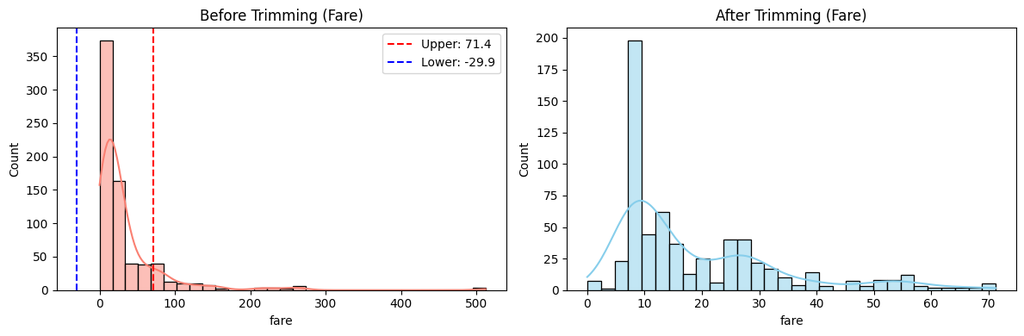

```python
# Compare distribution: Before vs After Trimming
fig, axes = plt.subplots(1, 2, figsize=(12, 4))

sns.histplot(df['fare'], kde=True, bins=30, ax=axes[0], color='salmon')
axes[0].axvline(upper_limit_iqr, color='red', linestyle='--', label=f'Upper: {upper_limit_iqr:.1f}')
axes[0].axvline(lower_limit_iqr, color='blue', linestyle='--', label=f'Lower: {lower_limit_iqr:.1f}')
axes[0].set_title('Before Trimming (Fare)')
axes[0].legend()

sns.histplot(df_trimmed_iqr['fare'], kde=True, bins=30, ax=axes[1], color='skyblue')
axes[1].set_title('After Trimming (Fare)')

plt.tight_layout()
plt.show()
```

#### Technique 2: Capping (Replace Outliers with Boundary Values)

```python
# Capping: Replace outlier fare values with boundary limits
df_capped_iqr = df.copy()

df_capped_iqr['fare'] = df_capped_iqr['fare'].apply(
    lambda x: upper_limit_iqr if x > upper_limit_iqr else (lower_limit_iqr if x < lower_limit_iqr else x)
)

print(f"Before capping - Fare range: {df['fare'].min():.2f} to {df['fare'].max():.2f}")
print(f"After capping  - Fare range: {df_capped_iqr['fare'].min():.2f} to {df_capped_iqr['fare'].max():.2f}")
print(f"Rows preserved: {df_capped_iqr.shape[0]} (no rows removed!)")
```

```
Before capping - Fare range: 0.00 to 512.33
After capping  - Fare range: 0.00 to 71.36
Rows preserved: 714 (no rows removed!)
```

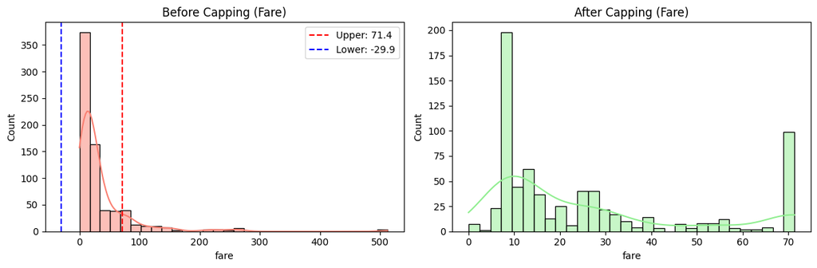

```python
# Compare distribution: Before vs After Capping
fig, axes = plt.subplots(1, 2, figsize=(12, 4))

sns.histplot(df['fare'], kde=True, bins=30, ax=axes[0], color='salmon')
axes[0].axvline(upper_limit_iqr, color='red', linestyle='--', label=f'Upper: {upper_limit_iqr:.1f}')
axes[0].axvline(lower_limit_iqr, color='blue', linestyle='--', label=f'Lower: {lower_limit_iqr:.1f}')
axes[0].set_title('Before Capping (Fare)')
axes[0].legend()

sns.histplot(df_capped_iqr['fare'], kde=True, bins=30, ax=axes[1], color='lightgreen')
axes[1].set_title('After Capping (Fare)')

plt.tight_layout()
plt.show()
```

### Side-by-Side Comparison: Original vs Trimmed vs Capped (IQR)

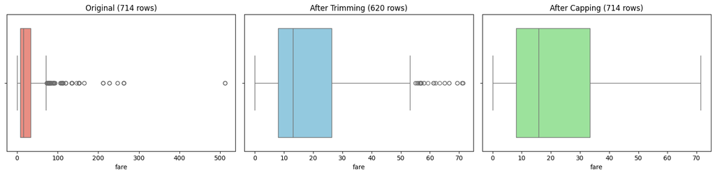

|  | Original | Trimmed (IQR) | Capped (IQR) |
| --- | --- | --- | --- |
| count | 714.00 | 620.00 | 714.00 |
| mean | 34.69 | 19.28 | 26.14 |
| std | 52.92 | 14.70 | 22.32 |
| min | 0.00 | 0.00 | 0.00 |
| 25% | 8.05 | 7.92 | 8.05 |
| 50% | 15.74 | 13.00 | 15.74 |
| 75% | 33.38 | 26.29 | 33.38 |
| max | 512.33 | 71.28 | 71.36 |

```python
# Final comparison: Original vs Trimmed vs Capped (Boxplots)
fig, axes = plt.subplots(1, 3, figsize=(16, 4))

sns.boxplot(x=df['fare'], ax=axes[0], color='salmon')
axes[0].set_title(f'Original ({df.shape[0]} rows)')

sns.boxplot(x=df_trimmed_iqr['fare'], ax=axes[1], color='skyblue')
axes[1].set_title(f'After Trimming ({df_trimmed_iqr.shape[0]} rows)')

sns.boxplot(x=df_capped_iqr['fare'], ax=axes[2], color='lightgreen')
axes[2].set_title(f'After Capping ({df_capped_iqr.shape[0]} rows)')

plt.tight_layout()
plt.show()

# Summary stats comparison
summary_iqr = pd.DataFrame({
    'Original': df['fare'].describe(),
    'Trimmed (IQR)': df_trimmed_iqr['fare'].describe(),
    'Capped (IQR)': df_capped_iqr['fare'].describe()
}).round(2)

summary_iqr
```